# midtermtesting_21600685

# Data Preparation and Exploration

Q1. csv 파일로 구성되어 있어서 read.csv() 함수를 이용해 데이터 프레임을 구축하였습니다.

```r
ins <- read.csv("C:/Users/sec/Downloads/insurance.csv")
```

```r
library(tidyr)
library(stringr)
library(dplyr)
library(lubridate)
```

Q2. 데이터셋은 행이 고객들의 observation 열이 고객마다 갖는 여러 건강 데이터들로 구축되어 있음 str(), glimpse()로 대략적으로 살펴보고 view()를 통해 한눈으로 알아보았다.

```r
glimpse(ins)
```

```
## Observations: 1,338
## Variables: 7
## $ age      <int> 19, 18, 28, 33, 32, 31, 46, 37, 37, 60, 25, 62, 23, 56, 27,…
## $ sex      <fct> female, male, male, male, male, female, female, female, mal…
## $ bmi      <dbl> 27.900, 33.770, 33.000, 22.705, 28.880, 25.740, 33.440, 27.…
## $ children <int> 0, 1, 3, 0, 0, 0, 1, 3, 2, 0, 0, 0, 0, 0, 0, 1, 1, 0, 0, 0,…
## $ smoker   <fct> yes, no, no, no, no, no, no, no, no, no, no, yes, no, no, y…
## $ region   <fct> southwest, southeast, southeast, northwest, northwest, sout…
## $ charges  <dbl> 16884.924, 1725.552, 4449.462, 21984.471, 3866.855, 3756.62…
```

```r
View(ins)
```

Q3.

```r
ins$bmi[which.max(ins$bmi)] # max범위 설정 위해
```

```
## [1] 53.13
```

```r
ins$bmi_range <- cut(ins$bmi, breaks = c(0, 18.5, 24.9, 53.13), right=T, labels = c("light", "normal", "heavy"))
tapply(ins$charges, ins$bmi_range, mean)
```

```
##     light    normal     heavy
##  8657.621 10404.900 13936.617
```

BMI가 가장 큰 경우가 가장 보험금이 많이 들었다. 반면 가장 작은 경우가 가장 보험금이 적게 들었다.

Q4.

```r
# 여성 남성 데이터 프레임 따로 구축!
ins_male <- ins[which(ins$sex=='male'), ]
ins_female <- ins[which(ins$sex=='female'), ]
# 남성의  평균 bmi
mean(ins_male$bmi)
```

```
## [1] 30.94313
```

```r
# 여성의 평균 bmi
mean(ins_female$bmi)
```

```
## [1] 30.37775
```

평균은 두 성별 대체로 비슷, 미세한 차이로 남성의 bmi가 살짝 높았음

분산의 경우는 다음과 같음

```r
var(ins_male$bmi)
```

```
## [1] 37.70494
```

```r
var(ins_female$bmi)
```

```
## [1] 36.5544
```

분산도도 어느정도 비슷

분포 그래프를 그려보면

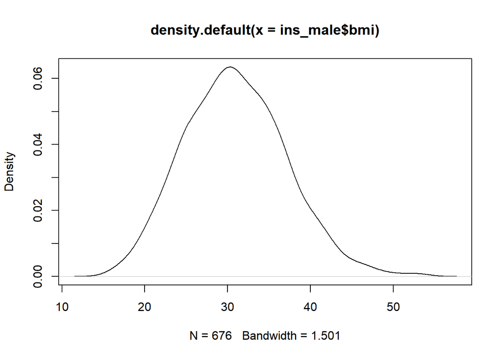

```r
plot(density(ins_male$bmi))
```

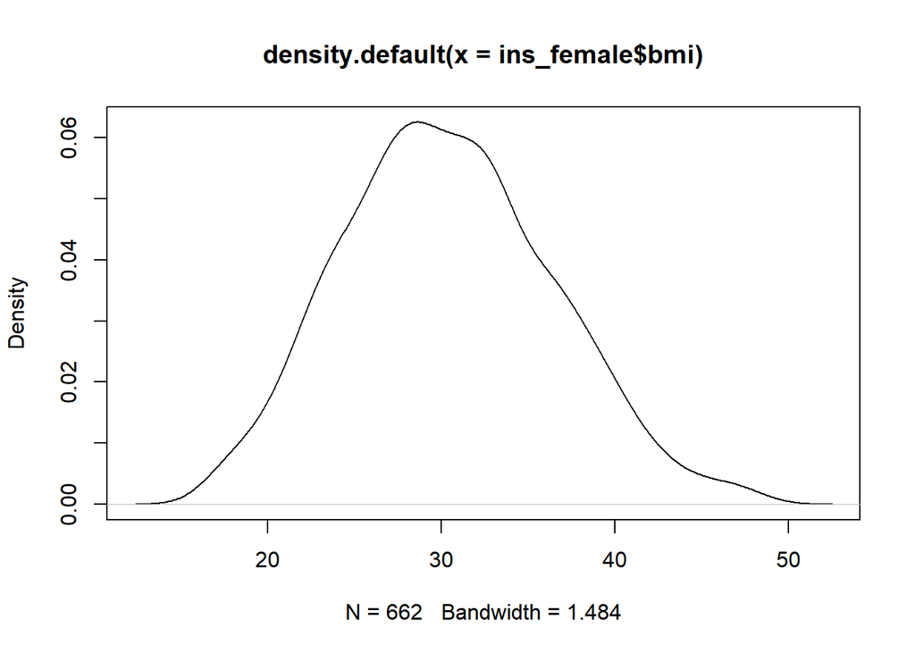

```r
plot(density(ins_female$bmi))
```

대체로 비슷함을 확인할 수 있다.

Q5. 보험 수령액의 분포를 보면 다음과 같다

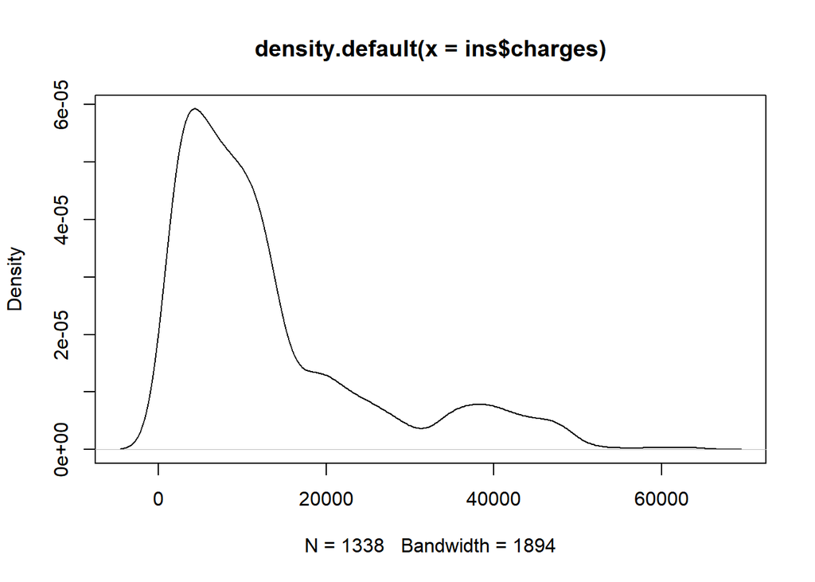

```r
plot(density(ins$charges))
```

보험 수령액이 적을 수록 그 빈도는 더 높게 나타났다. 반면 수랭의 규모가 큰 경우에 해당하는 고객의 빈도는 더 적었다. 대체적으로 보험의 수령 정도가 적은 사건들이 빈번하게 발생을 하고, 대형 사고나 규모가 큰 손해를 보는 경우가 비교적 빈도가 적게 되어 저러한 그래프가 나타나는 것으로 판단된다.

```r
tapply(ins$charges, ins$smoker, mean)
```

```
##        no       yes
##  8434.268 32050.232
```

Q7. 자녀들의 수에 따른 보험 징수액은 다음과 같다.

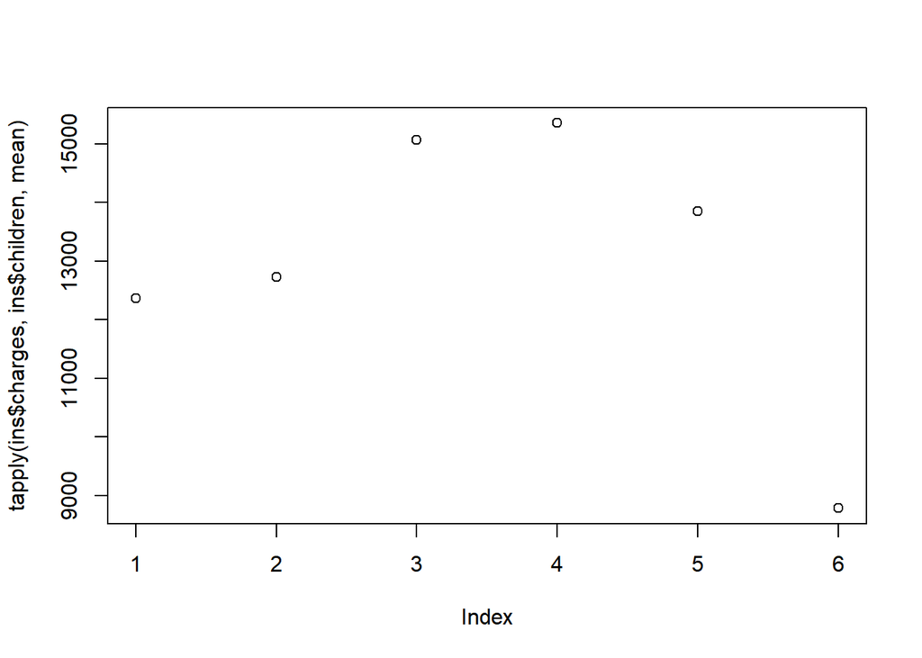

```r
plot(tapply(ins$charges, ins$children, mean))
```

그래프만 보면 자녀의 수가 많을 수록 보험료 징수액이 커지는 것 같지만, 5명일 경운는 오히려 보험료가 더 적게 나오는 양상을 보임

해당 점에 대한 관측치수(고객수)를 파악해보면

자녀가 1~2명 정도 되는 고객의 수는

```r
nrow(ins[which(ins$children==1), ])
```

```
## [1] 324
```

```r
nrow(ins[which(ins$children==2), ])
```

```
## [1] 240
```

3~4명 정도 되는 고객의 수

```r
nrow(ins[which(ins$children==3), ])
```

```
## [1] 157
```

```r
nrow(ins[which(ins$children==4), ])
```

```
## [1] 25
```

5명 고객의 수 – 이 경우 상대적 데이터의 수가 너무 적어 분석에 큰 영향을 줄 수는 없음

```r
nrow(ins[which(ins$children==5), ])
```

```
## [1] 18
```

plot의 결과를 보게 되면 1~2명의 고객 데이터보다 3~4명일 때의 고객의 경우가 더 보험료 수령액이 많았다. 이 말은 3~4명의 아이들일 경우에 더 많은 사고, 수슬 등이 더 많이 발생하여 보험료 수령의 금액의 크기가 더 큼을 의미한다.

Q8.

```r
quantile(ins$age, c(0.1,0.9))
```

```
## 10% 90%
##  19  59
```

```r
ins_young <- ins[which(ins$age<= 19), ]
ins_old <- ins[which(ins$age >= 59), ]
Y <- mean(ins_young$charges)
O <- mean(ins_old$charges)
O - Y
```

```
## [1] 12417.62
```

나이가 가장 많은 10%의 경우 59세 이상의 고객들이고 나이가 가장 어린 10%의 경우 19세 이하의 고객들이다.

평균적으로 두 고객 층의 보험료 징수액의 차이는 12417.62만큼 차이가 났다.

Q9.

```r
tapply(ins$charges, ins$sex, mean)
```

```
##   female     male
## 12569.58 13956.75
```

```r
13956.75 - 12569.58
```

```
## [1] 1387.17
```

남성의 경우가 여성의 경우보다 1387.17 정도 더 보험료 수급액이 높았다.

Q10. 남성의 경우 흡연자의 비율

```r
nrow(ins_male[which(ins_male$smoker == "yes"), ])/nrow(ins_male)
```

```
## [1] 0.2352071
```

여성의 경우 흠연자의 비율

```r
nrow(ins_male[which(ins_female$smoker == "yes"), ])/nrow(ins_female)
```

```
## [1] 0.173716
```

남성의 경우가 흡연자의 비율이 더 높음

```r
mean(ins_male$charges)
```

```
## [1] 13956.75
```

```r
mean(ins_female$charges)
```

```
## [1] 12569.58
```

평균적인 보험료 수급액도 남성이 더 높았다.

정확한 분석을 위해 보험료 금액에 대한 평균적인 변수의 영향력을 알아보기 위해 회귀분석을 실행한 결과

```r
summary(lm(ins$charges~ ins$age+ins$sex+ins$children+ins$smoker+ins$region))
```

```
##
## Call:
## lm(formula = ins$charges ~ ins$age + ins$sex + ins$children +
##     ins$smoker + ins$region)
##
## Residuals:
##      Min       1Q   Median       3Q      Max
## -15678.7  -1964.4  -1298.0   -358.5  28864.4
##
## Coefficients:
##                     Estimate Std. Error t value Pr(>|t|)
## (Intercept)         -2790.03     648.66  -4.301 1.82e-05 ***
## ins$age               273.33      12.42  22.003  < 2e-16 ***
## ins$sexmale            53.81     349.61   0.154 0.877693
## ins$children          496.46     144.85   3.428 0.000628 ***
## ins$smokeryes       23775.53     434.26  54.750  < 2e-16 ***
## ins$regionnorthwest  -345.64     500.66  -0.690 0.490084
## ins$regionsoutheast   389.17     487.11   0.799 0.424470
## ins$regionsouthwest  -484.20     500.63  -0.967 0.333629
## ---
## Signif. codes:  0 '***' 0.001 '**' 0.01 '*' 0.05 '.' 0.1 ' ' 1
##
## Residual standard error: 6372 on 1330 degrees of freedom
## Multiple R-squared:  0.7245, Adjusted R-squared:  0.7231
## F-statistic: 499.8 on 7 and 1330 DF,  p-value: < 2.2e-16
```

나이와 아이의 수, 흡연 여부가 중요한 변수로 여겨졌고 둘 다 양의 상관관계를 가졌고 R2는 0.7정도 나와 상당히 유의미한 관계로 여겨졌다. 흡연 여부가 굉장히 보험료 수급액에 큰 영향을 미침을 알 수 있다.

이는 남성의 경우와 여성의 경우를 따로 회귀분석을 실시해도 마찬가지의 결과를 갖는다.

```r
summary(lm(ins_male$charges~ ins_male$age+ins_male$children+ins_male$smoker+ins_male$region))
```

```
##
## Call:
## lm(formula = ins_male$charges ~ ins_male$age + ins_male$children +
##     ins_male$smoker + ins_male$region)
##
## Residuals:
##      Min       1Q   Median       3Q      Max
## -16738.7  -1756.2  -1234.6   -195.7  27789.3
##
## Coefficients:
##                          Estimate Std. Error t value Pr(>|t|)
## (Intercept)              -3186.80     885.13  -3.600 0.000341 ***
## ins_male$age               274.59      17.55  15.643  < 2e-16 ***
## ins_male$children          487.63     202.61   2.407 0.016367 *
## ins_male$smokeryes       25003.99     584.02  42.814  < 2e-16 ***
## ins_male$regionnorthwest  -191.18     712.72  -0.268 0.788595
## ins_male$regionsoutheast   629.75     685.61   0.919 0.358680
## ins_male$regionsouthwest  -407.85     709.74  -0.575 0.565722
## ---
## Signif. codes:  0 '***' 0.001 '**' 0.01 '*' 0.05 '.' 0.1 ' ' 1
##
## Residual standard error: 6406 on 669 degrees of freedom
## Multiple R-squared:  0.7583, Adjusted R-squared:  0.7561
## F-statistic: 349.8 on 6 and 669 DF,  p-value: < 2.2e-16
```

```r
summary(lm(ins_female$charges~ ins_female$age+ins_female$children+ins_female$smoker+ins_female$region))
```

```
##
## Call:
## lm(formula = ins_female$charges ~ ins_female$age + ins_female$children +
##     ins_female$smoker + ins_female$region)
##
## Residuals:
##      Min       1Q   Median       3Q      Max
## -13471.2  -1880.4  -1353.1   -505.5  29767.7
##
## Coefficients:
##                            Estimate Std. Error t value Pr(>|t|)
## (Intercept)                -2293.63     878.06  -2.612   0.0092 **
## ins_female$age               271.55      17.54  15.482   <2e-16 ***
## ins_female$children          481.26     206.89   2.326   0.0203 *
## ins_female$smokeryes       22197.59     649.95  34.153   <2e-16 ***
## ins_female$regionnorthwest  -439.85     700.99  -0.627   0.5306
## ins_female$regionsoutheast   100.91     689.96   0.146   0.8838
## ins_female$regionsouthwest  -631.73     703.91  -0.897   0.3698
## ---
## Signif. codes:  0 '***' 0.001 '**' 0.01 '*' 0.05 '.' 0.1 ' ' 1
##
## Residual standard error: 6315 on 655 degrees of freedom
## Multiple R-squared:  0.6809, Adjusted R-squared:  0.678
## F-statistic:   233 on 6 and 655 DF,  p-value: < 2.2e-16
```

흡연의 여부는 보험료 징수액에 굉장히 큰 영향을 미치게 되고 평균적으로 흡연율이 높은 남성의 경우가 더 보험 금액이 높게 나왔다.

# Tidy data

```r
auto <- read.table("C:/Users/sec/Downloads/automobile.tsv", header = T)
View(auto)
```

데이터 셋은 자동차의 observation의 위치에 같이 그 자동차의 변수가 되는 연비, 연식, 무게 등이 들어가 있다. 이 경우에는 열로 가야 tidy한 데이터가 되는데 이 경우는 전혀 tidy하지 않다. 고로 tidy 데이터의 형식으로 바꾸어 주어야 한다.

```r
auto <- spread(auto, specification, value)
head(auto)
```

```
##                car_name_year   origin acceleration cylinders displacement
## 1 amc ambassador brougham_73 domestic         11.0         8          360
## 2      amc ambassador dpl_70 domestic          8.5         8          390
## 3      amc ambassador sst_72 domestic         11.5         8          304
## 4         amc concord d/l_78 domestic         15.1         6          258
## 5        amc concord dl 6_79 domestic         18.2         6          232
## 6          amc concord dl_82 domestic         20.5         4          151
##   horsepower  mpg weight
## 1        175 13.0   3821
## 2        190 15.0   3850
## 3        150 17.0   3672
## 4        120 18.1   3410
## 5         90 20.2   3265
## 6         NA 23.0   3035
```

```r
save(auto, file = "automobile.RData")
```